# Assignment 2

Author

Allison Louie

```r
library(dplyr)
library(tidyverse)
library(tidyr)
library(ggplot2)
library(leaflet)
library(leaflet.providers)
library(R.utils)
```

## **Data Wrangling**

### 1. After merging the data, make sure you don’t have any duplicates by counting the number of rows.

```r
chs_individ <- read.csv("chs_individual.csv")
chs_region <- read.csv("chs_regional.csv")
chs_comb <- merge(chs_individ, chs_region, by.x = "townname", by.y = "townname")

dim(chs_comb)
```

```
[1] 1200   49
```

```r
chs_comb <- chs_comb %>%
  mutate(male = ifelse(is.na(male), mean(male, na.rm = TRUE), male),
         hispanic = ifelse(is.na(hispanic), mean(hispanic, na.rm = TRUE), hispanic))
```

### 2. Create a new categorical variable named “obesity_level” using the BMI measurement (underweight BMI<14; normal BMI 14-22; overweight BMI 22-24; obese BMI>24)

```r
categories <- c("Underweight", "Normal", "Overweight", "Obese")
chs_comb <- chs_comb[!is.na(chs_comb$bmi), ]
chs_comb$obesity_level <- cut(chs_comb$bmi,
                                        breaks = c(-Inf, 14, 22, 24, Inf),
                                        labels = categories)
summary_obesity <- chs_comb %>%
  group_by(obesity_level) %>%
  summarize(min_BMI = min(bmi),
            max_BMI = max(bmi),
            total_observations = n())
summary_obesity
```

```
# A tibble: 4 × 4
  obesity_level min_BMI max_BMI total_observations
  <fct>           <dbl>   <dbl>              <int>
1 Underweight      11.3    14.0                 35
2 Normal           14.0    22.0                886
3 Overweight       22.0    24.0                 87
4 Obese            24.0    41.3                103
```

### 3. Create another categorical variable named “smoke_gas_exposure” that summarizes “Second Hand Smoke” and “Gas Stove.” The variable should have four categories in total.

```r
chs_comb <- chs_comb %>%
  mutate(smoke_gas_exposure = case_when(
    smoke == 1 & gasstove == 1 ~ "Both",
    smoke == 1 ~ "Second Hand Smoke",
    gasstove == 1 ~ "Gas Stove",
    TRUE ~ "None"
  ))
unique(chs_comb$smoke_gas_exposure)
```

```
[1] "None"              "Gas Stove"         "Second Hand Smoke"
[4] "Both"
```

### 4. Create four summary tables showing the average (or proportion, if binary) and sd of “Forced expiratory volume in 1 second (ml)” and asthma indicator by town, sex, obesity level, and “smoke_gas_exposure.”

```r
summary_town <- chs_comb %>%
  filter(!is.na(asthma)) %>%
  group_by(townname) %>%
  summarize(avg_fev = mean(fev, na.rm = TRUE),
            sd_fev = sd(fev, na.rm = TRUE),
            avg_asthma = mean(asthma))
summary_town
```

```
# A tibble: 12 × 4
   townname      avg_fev sd_fev avg_asthma
   <chr>           <dbl>  <dbl>      <dbl>
 1 Alpine          2093.   301.      0.118
 2 Atascadero      2080.   334.      0.258
 3 Lake Elsinore   2039.   323.      0.126
 4 Lake Gregory    2092.   338.      0.154
 5 Lancaster       2003.   339.      0.153
 6 Lompoc          2043.   372.      0.125
 7 Long Beach      1980.   332.      0.144
 8 Mira Loma       1992.   335.      0.170
 9 Riverside       1986.   290.      0.109
10 San Dimas       2032.   320.      0.165
11 Santa Maria     2020.   331.      0.124
12 Upland          2030.   358.      0.120
```

```r
summary_male <- chs_comb %>%
  filter(!is.na(asthma)) %>%
  group_by(male) %>%
  summarize(avg_fev = mean(fev, na.rm = TRUE),
            sd_fev = sd(fev, na.rm = TRUE),
            avg_asthma = mean(asthma))
summary_male
```

```
# A tibble: 2 × 4
   male avg_fev sd_fev avg_asthma
  <int>   <dbl>  <dbl>      <dbl>
1     0   1958.   329.      0.119
2     1   2108.   318.      0.176
```

```r
summary_obesity <- chs_comb %>%
  filter(!is.na(asthma)) %>%
  group_by(obesity_level) %>%
  summarize(avg_fev = mean(fev, na.rm = TRUE),
            sd_fev = sd(fev, na.rm = TRUE),
            avg_asthma = mean(asthma))
summary_obesity
```

```
# A tibble: 4 × 4
  obesity_level avg_fev sd_fev avg_asthma
  <fct>           <dbl>  <dbl>      <dbl>
1 Underweight     1687.   300.     0.0857
2 Normal          1999.   310.     0.141
3 Overweight      2236.   311.     0.165
4 Obese           2273.   330.     0.21
```

```r
summary_smoke_gas <- chs_comb %>%
  filter(!is.na(asthma)) %>%
  group_by(smoke_gas_exposure) %>%
  summarize(avg_fev = mean(fev, na.rm = TRUE),
            sd_fev = sd(fev, na.rm = TRUE),
            avg_asthma = mean(asthma))
summary_smoke_gas
```

```
# A tibble: 4 × 4
  smoke_gas_exposure avg_fev sd_fev avg_asthma
  <chr>                <dbl>  <dbl>      <dbl>
1 Both                 2014.   317.      0.144
2 Gas Stove            2029.   330.      0.152
3 None                 2050.   347.      0.134
4 Second Hand Smoke    2084.   340.      0.161
```

## **Looking at the Data (EDA)**

```r
dim(chs_comb)
```

```
[1] 1111   51
```

```r
head(chs_comb)
```

```
  townname sid male race hispanic    agepft height weight      bmi asthma
1   Alpine 841    1    W        1 10.548939    150     78 15.75758      0
2   Alpine 835    0    W        0 10.099932    143     69 15.33749      0
3   Alpine 838    0    O        1  9.486653    133     62 15.93183      0
4   Alpine 840    0    W        0  9.965777    146     78 16.63283      0
5   Alpine 865    0    W        0 10.039699    162    140 24.24797      1
6   Alpine 867    0    W        1  9.957563    141     94 21.49151      0
  active_asthma father_asthma mother_asthma wheeze hayfever allergy educ_parent
1             0             0             0      0        0       0           5
2             0             0             0      0        0       1           3
3             0             0             0      0        0       0           4
4             0             0             0      0        0       0          NA
5             1             0             0      1        0       1           3
6             0            NA             0      0        0       0           5
  smoke pets gasstove      fev      fvc     mmef pm25_mass pm25_so4 pm25_no3
```

[output cut: 27 more lines]

```r
tail(chs_comb)
```

```
     townname  sid male race hispanic    agepft height weight      bmi asthma
1194   Upland 1864    0    B        0  9.190965    139     91 21.40864      0
1195   Upland 1866    0    O        1  9.806982    139     60 14.11559      0
1196   Upland 1867    0    M        1  9.618070    140     71 16.46568      0
1197   Upland 2033    0    M        0 10.121834    130     67 18.02044      0
1198   Upland 2031    1    W        0  9.798768    135     83 20.70084      0
1199   Upland 2032    1    W        0  9.549624    137     59 14.28855      0
     active_asthma father_asthma mother_asthma wheeze hayfever allergy
1194             0             1             0      1        1       1
1195             0            NA             0      0       NA      NA
1196             0             1             0      0        0       0
1197             1             0             0      1        1       0
1198             0             0             0      1        0       1
1199             0             0             1      1        1       1
     educ_parent smoke pets gasstove      fev      fvc     mmef pm25_mass
```

[output cut: 34 more lines]

```r
names(chs_comb)
```

```
 [1] "townname"           "sid"                "male"
 [4] "race"               "hispanic"           "agepft"
 [7] "height"             "weight"             "bmi"
[10] "asthma"             "active_asthma"      "father_asthma"
[13] "mother_asthma"      "wheeze"             "hayfever"
[16] "allergy"            "educ_parent"        "smoke"
[19] "pets"               "gasstove"           "fev"
[22] "fvc"                "mmef"               "pm25_mass"
[25] "pm25_so4"           "pm25_no3"           "pm25_nh4"
[28] "pm25_oc"            "pm25_ec"            "pm25_om"
[31] "pm10_oc"            "pm10_ec"            "pm10_tc"
[34] "formic"             "acetic"             "hcl"
[37] "hno3"               "o3_max"             "o3106"
[40] "o3_24"              "no2"                "pm10"
[43] "no_24hr"            "pm2_5_fr"           "iacid"
[46] "oacid"              "total_acids"        "lon"
[49] "lat"                "obesity_level"      "smoke_gas_exposure"
```

```r
str(chs_comb)
```

```
'data.frame':   1111 obs. of  51 variables:
 $ townname          : chr  "Alpine" "Alpine" "Alpine" "Alpine" ...
 $ sid               : int  841 835 838 840 865 867 842 839 844 847 ...
 $ male              : int  1 0 0 0 0 0 1 0 1 1 ...
 $ race              : chr  "W" "W" "O" "W" ...
 $ hispanic          : int  1 0 1 0 0 1 1 1 1 0 ...
 $ agepft            : num  10.55 10.1 9.49 9.97 10.04 ...
 $ height            : int  150 143 133 146 162 141 139 142 143 137 ...
 $ weight            : int  78 69 62 78 140 94 65 86 65 69 ...
 $ bmi               : num  15.8 15.3 15.9 16.6 24.2 ...
 $ asthma            : int  0 0 0 0 1 0 0 0 NA 0 ...
 $ active_asthma     : int  0 0 0 0 1 0 0 0 0 0 ...
 $ father_asthma     : int  0 0 0 0 0 NA 0 0 NA 0 ...
 $ mother_asthma     : int  0 0 0 0 0 0 0 1 NA 0 ...
 $ wheeze            : int  0 0 0 0 1 0 1 1 NA 0 ...
```

[output cut: 37 more lines]

```r
summary(chs_comb)
```

```
   townname              sid              male            race
 Length:1111        Min.   :   1.0   Min.   :0.0000   Length:1111
 Class :character   1st Qu.: 520.5   1st Qu.:0.0000   Class :character
 Mode  :character   Median :1035.0   Median :0.0000   Mode  :character
                    Mean   :1034.3   Mean   :0.4977
                    3rd Qu.:1547.5   3rd Qu.:1.0000
                    Max.   :2050.0   Max.   :1.0000

    hispanic          agepft           height        weight
 Min.   :0.0000   Min.   : 8.961   Min.   :114   Min.   : 42.00
 1st Qu.:0.0000   1st Qu.: 9.610   1st Qu.:135   1st Qu.: 65.00
 Median :0.0000   Median : 9.906   Median :139   Median : 74.00
 Mean   :0.4374   Mean   : 9.924   Mean   :139   Mean   : 79.33
 3rd Qu.:1.0000   3rd Qu.:10.177   3rd Qu.:143   3rd Qu.: 89.00
 Max.   :1.0000   Max.   :12.731   Max.   :165   Max.   :207.00

      bmi            asthma       active_asthma    father_asthma
 Min.   :11.30   Min.   :0.0000   Min.   :0.0000   Min.   :0.00000
 1st Qu.:15.78   1st Qu.:0.0000   1st Qu.:0.0000   1st Qu.:0.00000
 Median :17.48   Median :0.0000   Median :0.0000   Median :0.00000
 Mean   :18.50   Mean   :0.1475   Mean   :0.1917   Mean   :0.08047
 3rd Qu.:20.35   3rd Qu.:0.0000   3rd Qu.:0.0000   3rd Qu.:0.00000
 Max.   :41.27   Max.   :1.0000   Max.   :1.0000   Max.   :1.00000
                 NA's   :26                        NA's   :92
 mother_asthma         wheeze          hayfever         allergy
 Min.   :0.00000   Min.   :0.0000   Min.   :0.0000   Min.   :0.0000
 1st Qu.:0.00000   1st Qu.:0.0000   1st Qu.:0.0000   1st Qu.:0.0000
 Median :0.00000   Median :0.0000   Median :0.0000   Median :0.0000
 Mean   :0.09774   Mean   :0.3368   Mean   :0.1781   Mean   :0.2917
 3rd Qu.:0.00000   3rd Qu.:1.0000   3rd Qu.:0.0000   3rd Qu.:1.0000
 Max.   :1.00000   Max.   :1.0000   Max.   :1.0000   Max.   :1.0000
 NA's   :47        NA's   :63       NA's   :106      NA's   :55
  educ_parent        smoke             pets           gasstove
 Min.   :1.000   Min.   :0.0000   Min.   :0.0000   Min.   :0.0000
 1st Qu.:2.000   1st Qu.:0.0000   1st Qu.:1.0000   1st Qu.:1.0000
 Median :3.000   Median :0.0000   Median :1.0000   Median :1.0000
 Mean   :2.821   Mean   :0.1561   Mean   :0.7741   Mean   :0.7851
 3rd Qu.:3.000   3rd Qu.:0.0000   3rd Qu.:1.0000   3rd Qu.:1.0000
 Max.   :5.000   Max.   :1.0000   Max.   :1.0000   Max.   :1.0000
 NA's   :57      NA's   :35                        NA's   :27
```

[output cut: 46 more lines]

```
 Max.   :70.39   Max.   :42.95   Max.   :31.55   Max.   :4.620
                 NA's   :91      NA's   :274
     oacid        total_acids          lon              lat
 Min.   :1.090   Min.   : 1.520   Min.   :-120.7   Min.   :32.84
 1st Qu.:3.020   1st Qu.: 5.300   1st Qu.:-118.2   1st Qu.:33.77
 Median :4.510   Median : 7.180   Median :-117.6   Median :34.10
 Mean   :4.365   Mean   : 6.745   Mean   :-118.3   Mean   :34.20
 3rd Qu.:7.010   3rd Qu.:10.370   3rd Qu.:-117.4   3rd Qu.:34.64
 Max.   :7.400   Max.   :11.430   Max.   :-116.8   Max.   :35.49

     obesity_level smoke_gas_exposure
 Underweight: 35   Length:1111
 Normal     :886   Class :character
 Overweight : 87   Mode  :character
 Obese      :103
```

### 1. What is the association between BMI and FEV (forced expiratory volume)?

```r
fev_bmi_summary <- chs_comb %>%
  group_by(obesity_level) %>%
  summarize(mean_fev = mean(fev, na.rm = TRUE))
fev_bmi_summary
```

```
# A tibble: 4 × 2
  obesity_level mean_fev
  <fct>            <dbl>
1 Underweight      1687.
2 Normal           1998.
3 Overweight       2224.
4 Obese            2269.
```

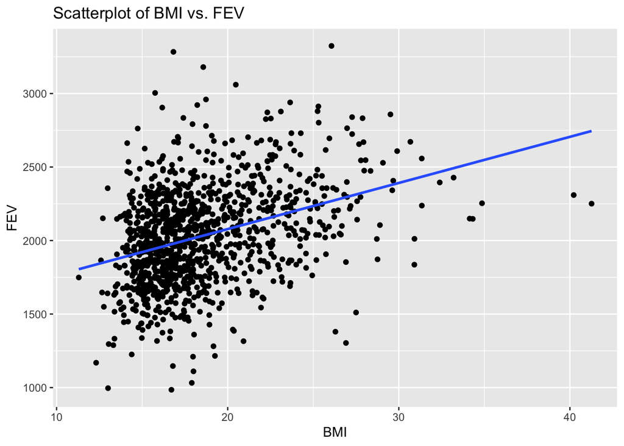

```r
chs_comb <- chs_comb[!is.na(chs_comb$fev) & is.finite(chs_comb$fev), ]
ggplot(chs_comb, aes(x = bmi, y = fev)) +
  geom_point() +
  geom_smooth(method = "lm", se = FALSE) +
  labs(title = "Scatterplot of BMI vs. FEV",
       x = "BMI",
       y = "FEV")
```

It seems that for the towns, BMI and FEV have an overall positive relationship with each other when looking at the regression model. When looking at the obesity levels, the mean appears to be increasing throughout the different levels from “Underweight” to “Obese.”

### 2. What is the association between smoke and gas exposure and FEV?

```r
fev_gas_summary <- chs_comb %>%
  group_by(smoke_gas_exposure) %>%
  summarize(mean_fev = mean(fev, na.rm = TRUE))
fev_gas_summary
```

```
# A tibble: 4 × 2
  smoke_gas_exposure mean_fev
  <chr>                 <dbl>
1 Both                  2020.
2 Gas Stove             2028.
3 None                  2041.
4 Second Hand Smoke     2084.
```

The association between FEV and smoke and gas exposure appears to be relatively even throughout the different levels. There seems to be not much of a wide variance between the different categories of smoke and gas exposure.

### 3. What is the association between PM2.5 exposure and FEV?

```r
fev_pm_summary <- chs_comb %>%
  group_by(pm25_mass) %>%
  summarize(mean_fev = mean(fev, na.rm = TRUE))
fev_pm_summary
```

```
# A tibble: 12 × 2
   pm25_mass mean_fev
       <dbl>    <dbl>
 1      5.96    2038.
 2      7.19    2023.
 3      7.48    2079.
 4      7.66    2092.
 5      8.5     2003.
 6      8.74    2089.
 7     12.4     2040.
 8     19.1     1984.
 9     20.5     2028.
10     22.4     1986.
11     22.5     2027.
12     30.0     1985.
```

The association between PM2.5 exposure and FEV seems to be somewhat negative. There is a little bit of change between the two variables, but it still seems there is an association.

## **Visualization**

### 1. Facet plot showing scatterplots with regression lines of BMI vs FEV by “townname”

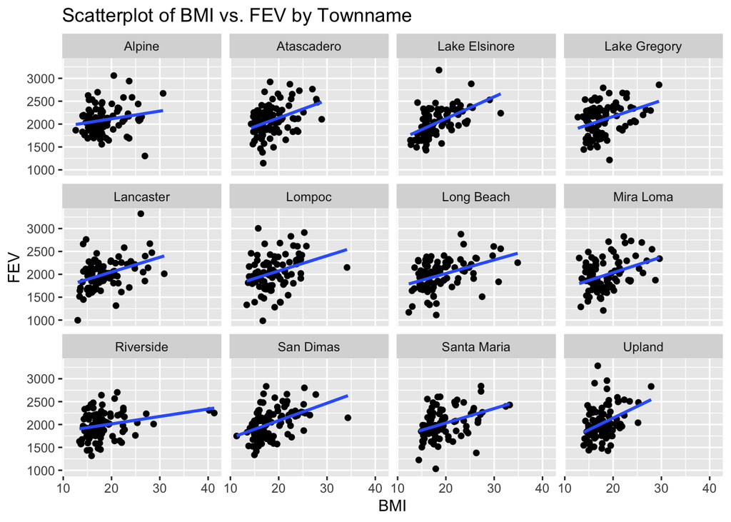

```r
ggplot(chs_comb, aes(x = bmi, y = fev)) +
  geom_point() +
  geom_smooth(method = "lm", se = FALSE) +
  facet_wrap(~townname) +
  labs(title = "Scatterplot of BMI vs. FEV by Townname",
       x = "BMI",
       y = "FEV")
```

It seems that organized by towns, BMI and FEV have an overall relatively positive relationship with each other.

### 2. Stacked histograms of FEV by BMI category and FEV by smoke/gas exposure

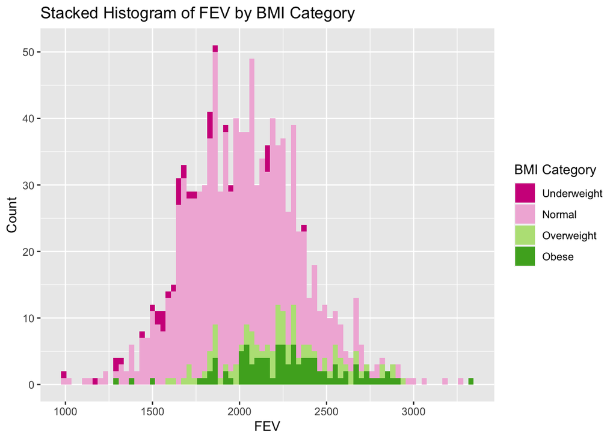

```r
ggplot(chs_comb, aes(x = fev, fill = obesity_level)) +
  geom_histogram(binwidth = 30, position = "stack") +
  labs(title = "Stacked Histogram of FEV by BMI Category",
       x = "FEV",
       y = "Count") +
 scale_fill_brewer(palette = "PiYG", name = "BMI Category",
                    labels = c("Underweight", "Normal", "Overweight", "Obese"))
```

[figure not shown]

```r
ggplot(chs_comb, aes(x = fev, fill = smoke_gas_exposure)) +
  geom_histogram(binwidth = 30, position = "stack") +
  labs(title = "Stacked Histogram of FEV by Smoke/Gas Exposure",
       x = "FEV",
       y = "Count") +
     scale_fill_brewer(palette = "PiYG", name = "Smoke/Gas Exposure",
                    labels = c("None", "Smoke", "Gas Stove", "Both"))
```

### 3. Barchart of BMI by smoke/gas exposure

[figure not shown]

```r
ggplot(chs_comb, aes(x = smoke_gas_exposure, y = bmi, fill = smoke_gas_exposure)) +
  geom_bar(stat = "summary", fun = "mean") +
  labs(title = "Bar Chart of BMI by Smoke/Gas Exposure",
       x = "Smoke/Gas Exposure",
       y = "Mean BMI") +
   scale_fill_brewer(palette = "PiYG", name = "Smoke/Gas Exposure",
                    labels = c("None", "Smoke", "Gas Stove", "Both"))
```

### 4. Statistical summary graphs of FEV by BMI and FEV by smoke/gas exposure category

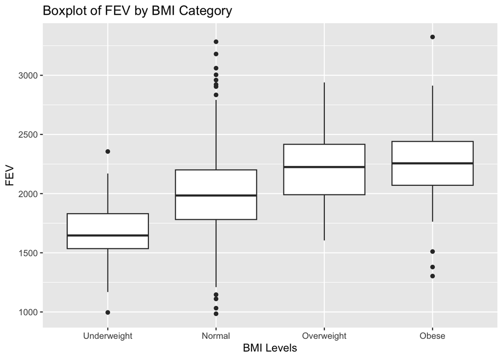

```r
ggplot(chs_comb, aes(x = obesity_level, y = fev)) +
  geom_boxplot() +
  labs(title = "Boxplot of FEV by BMI Category",
       x = "BMI Levels",
       y = "FEV")
```

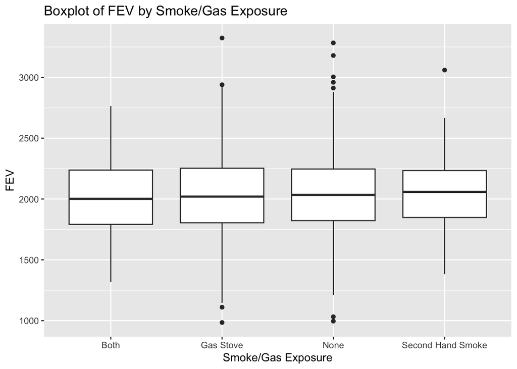

```r
ggplot(chs_comb, aes(x = smoke_gas_exposure, y = fev)) +
  geom_boxplot() +
  labs(title = "Boxplot of FEV by Smoke/Gas Exposure",
       x = "Smoke/Gas Exposure",
       y = "FEV")
```

### 5. A leaflet map showing the concentrations of PM2.5 mass in each of the CHS communities

```r
leaflet(chs_comb) %>%
  addTiles() %>%
  addCircleMarkers(
    ~lon,
    ~lat,
    radius = ~pm25_mass,
    color = "green",
    stroke = FALSE,
    fillOpacity = 0.5,
    popup = ~paste("Community: ", townname, "<br>PM2.5 Mass: ", pm25_mass, " µg/m³"),
    label = ~townname
  ) %>%
  addLegend("bottomright", colors = "green", labels = "PM2.5 Mass")
```

[interactive chart not shown]

### 6. Choose a visualization to examine whether PM2.5 mass is associated with FEV

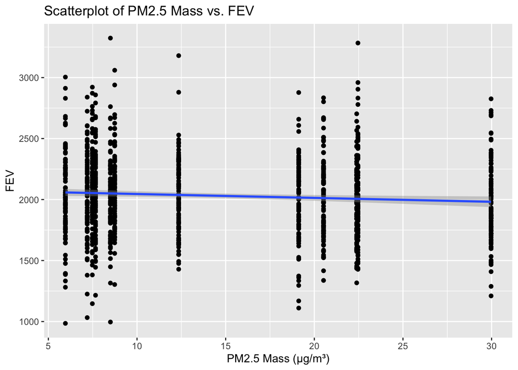

```r
ggplot(chs_comb, aes(x = pm25_mass, y = fev)) +
  geom_point() +
  geom_smooth(method = "lm") +
  labs(title = "Scatterplot of PM2.5 Mass vs. FEV",
       x = "PM2.5 Mass (µg/m³)",
       y = "FEV")
```